# Replication of Ancova studies

Fri Nov 1 09:58:47 2019

## Ancova

## Ancova is not Anova

**Definitions** - The rationale for ANCOVA is to quantify the unexplained variance that is unassociated with the existing independant variable. - An ANOVA is a type of linear regression model, an ANCOVA is an ANOVA, which accounts for potential confounders which are usually continuous - An ANCOVA model is the analysis of covariance between the outcome and independant variables which are discrete and covariates which are continuous.

## Motivation

**Libido Study**

- Initial one-way ANOVA show that there is no evidence of significant relationship between dose and libido, motivates to evaluate its underlying covariances to answer :
- What is the variance explained by three doses of Viagra on Libido?
- And what is the variance explained by Partner Libido on Libido.

```r
first_mod <- aov( libido ~dose, data=viagraData)
summary(first_mod)
```

```
##             Df Sum Sq Mean Sq F value Pr(>F)
## dose         2  16.84   8.422   2.416  0.108
## Residuals   27  94.12   3.486
```

## Explore Data

- Boxplot shows: Does different doses produce different outcomes

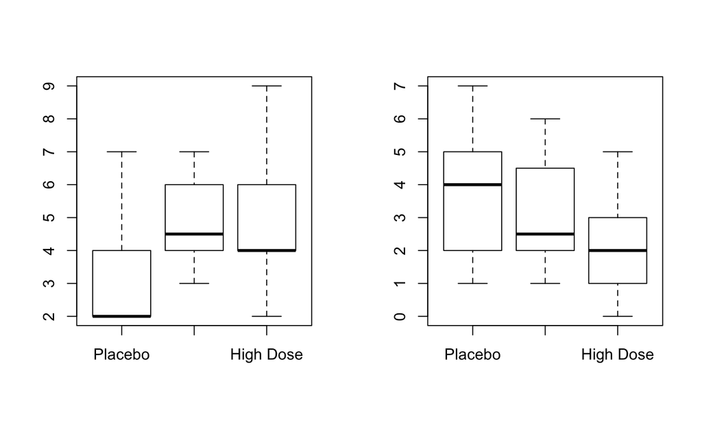

## Explore Data : Descriptives

- Descriptive Statistics

```r
by(viagraData$libido, viagraData$dose, stat.desc)
```

```
## viagraData$dose: Placebo
##      nbr.val     nbr.null       nbr.na          min          max
##    9.0000000    0.0000000    0.0000000    2.0000000    7.0000000
##        range          sum       median         mean      SE.mean
##    5.0000000   29.0000000    2.0000000    3.2222222    0.5957670
## CI.mean.0.95          var      std.dev     coef.var
##    1.3738411    3.1944444    1.7873009    0.5546796
## --------------------------------------------------------
## viagraData$dose: Low Dose
##      nbr.val     nbr.null       nbr.na          min          max
##    8.0000000    0.0000000    0.0000000    3.0000000    7.0000000
##        range          sum       median         mean      SE.mean
##    4.0000000   39.0000000    4.5000000    4.8750000    0.5153882
## CI.mean.0.95          var      std.dev     coef.var
##    1.2186994    2.1250000    1.4577380    0.2990232
## --------------------------------------------------------
## viagraData$dose: High Dose
##      nbr.val     nbr.null       nbr.na          min          max
##   13.0000000    0.0000000    0.0000000    2.0000000    9.0000000
##        range          sum       median         mean      SE.mean
##    7.0000000   63.0000000    4.0000000    4.8461538    0.5866698
## CI.mean.0.95          var      std.dev     coef.var
##    1.2782437    4.4743590    2.1152681    0.4364839
```

```r
by(viagraData$partnerLibido, viagraData$dose, stat.desc)
```

```
## viagraData$dose: Placebo
##      nbr.val     nbr.null       nbr.na          min          max
##    9.0000000    0.0000000    0.0000000    1.0000000    7.0000000
##        range          sum       median         mean      SE.mean
##    6.0000000   31.0000000    4.0000000    3.4444444    0.6894263
## CI.mean.0.95          var      std.dev     coef.var
##    1.5898199    4.2777778    2.0682789    0.6004681
## --------------------------------------------------------
## viagraData$dose: Low Dose
##      nbr.val     nbr.null       nbr.na          min          max
##    8.0000000    0.0000000    0.0000000    1.0000000    6.0000000
##        range          sum       median         mean      SE.mean
##    5.0000000   25.0000000    2.5000000    3.1250000    0.6105472
## CI.mean.0.95          var      std.dev     coef.var
##    1.4437147    2.9821429    1.7268882    0.5526042
## --------------------------------------------------------
## viagraData$dose: High Dose
##      nbr.val     nbr.null       nbr.na          min          max
##   13.0000000    3.0000000    0.0000000    0.0000000    5.0000000
##        range          sum       median         mean      SE.mean
##    5.0000000   26.0000000    2.0000000    2.0000000    0.4529108
## CI.mean.0.95          var      std.dev     coef.var
##    0.9868079    2.6666667    1.6329932    0.8164966
```

## Explore Data : Graphical analysis for homogeneity of regression slopes

- Say we want to know the overall relationship between Viagra and Partner libido, ignoring which dose groups the data points belong to, we therefore assume that the relationship between dose group and partner libido is constant across all doses. If the latter is not true, then the overall relationship between Viagra and Partner libido is inaccurate.
- there is homogeneity of regression slopes for Placebo and Lower doses
- there is no homogeneity of regression slopes for Placebo and High dose
- That's ok because there are situations where you might actually expect regression slopes to differ across groups and that this is, in itself, an interesting hypothesis.

## Graphical Anaylsis for homogeneity of regression slopes

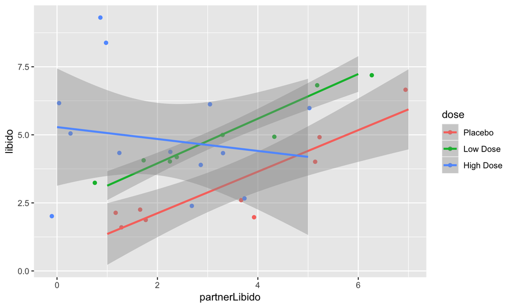

## Assumption 1 : Homogeneity of variance

- Levene's Test: Are the variances between doses on libido very similar ?
- A good double-check of Levene’s test is to look at the highest and lowest variances. For our three groups we have standard deviations of 1.79 (placebo), 1.46 (low dose) and 2.12 (high dose)

```r
leveneTest(viagraData$libido, viagraData$dose, center = median)
```

```
## Levene's Test for Homogeneity of Variance (center = median)
##       Df F value Pr(>F)
## group  2  0.3256 0.7249
##       27
```

## Assumption 2 : Check that the covariate and any independent variables are independent

- We run an ANOVA to find out if the covariance independant to each of the three doses?
- The summary results show that on low and high doses, there is no evidence of significant association of these doses to partner libido.

```r
checkIndependenceModel<-aov(partnerLibido ~ dose, data = viagraData)
summary(checkIndependenceModel)
```

```
##             Df Sum Sq Mean Sq F value Pr(>F)
## dose         2  12.77   6.385   1.979  0.158
## Residuals   27  87.10   3.226
```

```r
summary.lm(checkIndependenceModel)
```

```
##
## Call:
## aov(formula = partnerLibido ~ dose, data = viagraData)
##
## Residuals:
##     Min      1Q  Median      3Q     Max
## -2.4444 -1.3646 -0.0625  1.0000  3.5556
##
## Coefficients:
##               Estimate Std. Error t value Pr(>|t|)
## (Intercept)     3.4444     0.5987   5.753 4.06e-06 ***
## doseLow Dose   -0.3194     0.8727  -0.366   0.7172
## doseHigh Dose  -1.4444     0.7788  -1.855   0.0746 .
## ---
## Signif. codes:  0 '***' 0.001 '**' 0.01 '*' 0.05 '.' 0.1 ' ' 1
##
## Residual standard error: 1.796 on 27 degrees of freedom
## Multiple R-squared:  0.1279, Adjusted R-squared:  0.06326
## F-statistic: 1.979 on 2 and 27 DF,  p-value: 0.1577
```

## Running the ANCOVA

```r
ancova_mod <- aov(libido ~dose + partnerLibido, data= viagraData)
summary(ancova_mod)
```

```
##               Df Sum Sq Mean Sq F value Pr(>F)
## dose           2  16.84   8.422   2.770 0.0812 .
## partnerLibido  1  15.08  15.076   4.959 0.0348 *
## Residuals     26  79.05   3.040
## ---
## Signif. codes:  0 '***' 0.001 '**' 0.01 '*' 0.05 '.' 0.1 ' ' 1
```

## Interpreting the main effects of ANCOVA

- We run the ANCOVA model and compute the variance per dose group
- The command aov will calculate the ANCOVA, though it is also used with ANOVA
- The Anova command shows the same output of the summary.lm command. The former specifies the Type III sum of squares used to compute the analyses variances
- The Anova results of the viagraModel here show that there is evidence of significant effect of partner libido on libido.

## Main effects of ANCOVA

```
##
## Call:
## aov(formula = libido ~ partnerLibido + dose, data = viagraData)
##
## Residuals:
##     Min      1Q  Median      3Q     Max
## -3.2622 -0.7899 -0.3230  0.8811  4.5699
##
## Coefficients:
##               Estimate Std. Error t value Pr(>|t|)
## (Intercept)     3.1260     0.6250   5.002 3.34e-05 ***
## partnerLibido   0.4160     0.1868   2.227  0.03483 *
## dose1           0.6684     0.2400   2.785  0.00985 **
## dose2           0.2196     0.4056   0.541  0.59284
## ---
## Signif. codes:  0 '***' 0.001 '**' 0.01 '*' 0.05 '.' 0.1 ' ' 1
##
## Residual standard error: 1.744 on 26 degrees of freedom
## Multiple R-squared:  0.2876, Adjusted R-squared:  0.2055
## F-statistic:   3.5 on 3 and 26 DF,  p-value: 0.02954
```

```
## Anova Table (Type III tests)
##
## Response: libido
##               Sum Sq Df F value    Pr(>F)
## (Intercept)   76.069  1 25.0205 3.342e-05 ***
## partnerLibido 15.076  1  4.9587   0.03483 *
## dose          25.185  2  4.1419   0.02745 *
## Residuals     79.047 26
## ---
## Signif. codes:  0 '***' 0.001 '**' 0.01 '*' 0.05 '.' 0.1 ' ' 1
```

## Main effects of ANCOVA II

```
## Anova Table (Type III tests)
##
## Response: libido
##               Sum Sq Df F value    Pr(>F)
## (Intercept)   76.069  1 25.0205 3.342e-05 ***
## partnerLibido 15.076  1  4.9587   0.03483 *
## dose          25.185  2  4.1419   0.02745 *
## Residuals     79.047 26
## ---
## Signif. codes:  0 '***' 0.001 '**' 0.01 '*' 0.05 '.' 0.1 ' ' 1
```

## Residuals vs Fitted : Testing for Homogeneity of Variance

- The residuals for fitted value are similar to zero

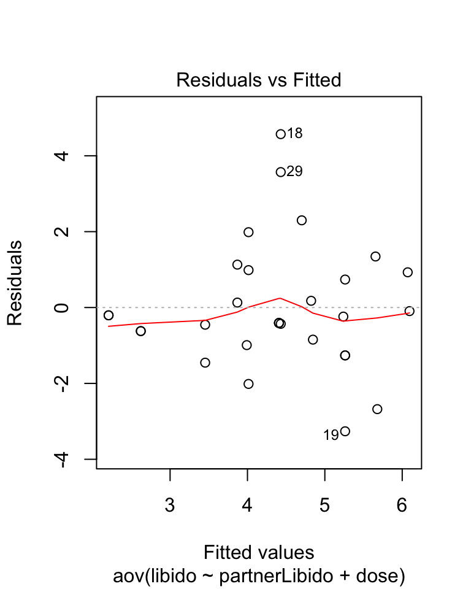

## QQ plots

- Residuals are normally distributed
- estimate in each case is the difference between the adjusted group means

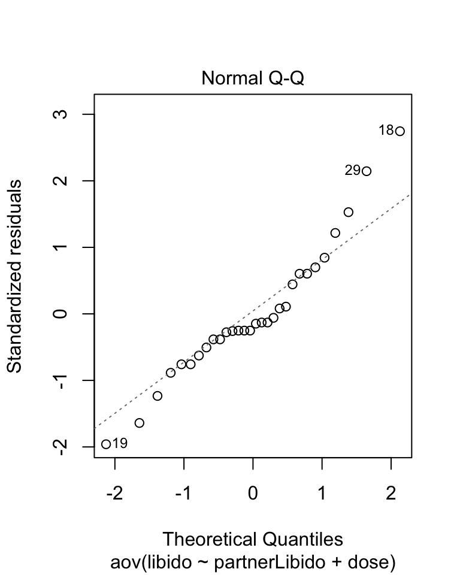

## Post Hoc Tests

- A Tukey-Ascombe test is performed via a general linear hypotheses function from library(multcomp).
- It is used for a pairwise comparison t test between doses for between groups differences
- In other words: we want to test differences between the adjusted means.
- In this case, the differences between Higher dose and Placebo can be compared with evidence of significance.
- In this method, we are restricted to the Tukey and the Dunnett method.

```r
postHocs<-glht(viagraModel, linfct = mcp(dose = "Tukey"))
summary(postHocs)
```

```
##
##   Simultaneous Tests for General Linear Hypotheses
##
## Multiple Comparisons of Means: Tukey Contrasts
##
##
## Fit: aov(formula = libido ~ partnerLibido + dose, data = viagraData)
##
## Linear Hypotheses:
##                           Estimate Std. Error t value Pr(>|t|)
## Low Dose - Placebo == 0     1.7857     0.8494   2.102   0.1090
## High Dose - Placebo == 0    2.2249     0.8028   2.771   0.0266 *
## High Dose - Low Dose == 0   0.4392     0.8112   0.541   0.8516
## ---
## Signif. codes:  0 '***' 0.001 '**' 0.01 '*' 0.05 '.' 0.1 ' ' 1
## (Adjusted p values reported -- single-step method)
```

```r
confint(postHocs)
```

```
##
##   Simultaneous Confidence Intervals
##
## Multiple Comparisons of Means: Tukey Contrasts
##
##
## Fit: aov(formula = libido ~ partnerLibido + dose, data = viagraData)
##
## Quantile = 2.4845
## 95% family-wise confidence level
##
##
## Linear Hypotheses:
##                           Estimate lwr     upr
## Low Dose - Placebo == 0    1.7857  -0.3245  3.8959
## High Dose - Placebo == 0   2.2249   0.2303  4.2195
## High Dose - Low Dose == 0  0.4392  -1.5763  2.4547
```

## Going back to Basic Assumptions : Homogeneity of Regression Slopes

- "The significant between interaction effect and dose show that the assumption is not tenable..
- "Although this finding is not surprising given the pattern of relationships, it does raise concern about the main analysis. This example illustrates why it is important to test assumptions and not to just blindly accept the results of an analysis"

```r
hoRS<-aov(libido ~ partnerLibido*dose, data = viagraData)
hoRS<-update(viagraModel, .~. + partnerLibido:dose)
Anova(hoRS, type="III")
```

```
## Anova Table (Type III tests)
##
## Response: libido
##                    Sum Sq Df F value    Pr(>F)
## (Intercept)        53.542  1 21.9207 9.323e-05 ***
## partnerLibido      17.182  1  7.0346   0.01395 *
## dose               36.558  2  7.4836   0.00298 **
## partnerLibido:dose 20.427  2  4.1815   0.02767 *
## Residuals          58.621 24
## ---
## Signif. codes:  0 '***' 0.001 '**' 0.01 '*' 0.05 '.' 0.1 ' ' 1
```

## Summary and Conclusion

- ANOVA is not ANCOVA because the latter accounts for analysis of variance of the covariate or covariates
- Interpretation of ANCOVA depends on the order in the aov(…) function
- Basic Assumptions are important because for example the overall conclusion of the relationship between Viagra and Libido must be based on an independance assumption between covariates and dose of Viagra
- Thus the conclusion that Partner libido has a significant influence on Libido under three condition of Viagra dose, is inaccurate.